# Reguły Sekwencyjne dla pacjentów chorych na cukrzycę.

Ludwik Przyrowski, Adam Kolipiński

7 maja 2017

## Opis i specyfika zadania

W obliczeń zostana użyte następujace boblioteki:

```r
library(arules)
library(arulesSequences)
library(ggplot2)
library(dplyr)
```

## Eksploracja danych wejściowych

Do zadania posłużyły dane wejściowe ze zbioru UCI Machine Learning Repository (https://archive.ics.uci.edu/ml/datasets/Diabetes) opracowane początkowo poprzez Michael Kahn, MD, PhD, Washington University, St. Louis, MO a następnie przetworzone w Politechnice Warszawskiej na potrzeby laboratorium.

```r
download.file('http://staff.ii.pw.edu.pl/~gprotazi/dydaktyka/dane/diab_trans.data', destfile = 'data/diab_trans.data')
diab.df <- read.csv("data/diab_trans.data", header=TRUE, stringsAsFactors = FALSE)
```

```r
head(diab.df)
```

```
##   patient_id time_sek  code value
## 1          1 96772141 id_58   100
## 2          1 96772142 id_33     9
## 3          1 96772143 id_34    13
## 4          1 96800881 id_62   119
## 5          1 96800882 id_33     7
## 6          1 96821461 id_48   123
```

Dla lepszego zrozumienia danych zmiennej ‘code’ zostały przypisane opisy zdarzeń

```r
diab.df$code_id = as.numeric(substring(diab.df$code, 4,5))
description.df <- read.csv('data/description.txt', header=TRUE)

input.df <- inner_join(diab.df,description.df)
head(select(input.df, code_id, description_PL))
```

```
##   code_id                                     description_PL
## 1      58 Pomiar zawartości glukozy we krwi przed śniadaniem
## 2      33                          Dawka insuliny regularnej
## 3      34                                 Dawka insuliny NPH
## 4      62    Pomiar zawartości glukozy we krwi przed kolacją
## 5      33                          Dawka insuliny regularnej
## 6      48     Nieokreślony pomiar zawartości glukozy we krwi
```

Tylko niektóre typy wydarzeń mają znaczącą wartość zmiennej ‘value’, w reszcie przypisana jest cyfra 0

```r
to_chunk.df = input.df %>%
  group_by(code_id) %>%
  distinct(value) %>%
  summarise(count=n()) %>%
  filter(count>1)
to_chunk.df$measure = TRUE

base.df <- left_join(input.df, to_chunk.df)
dawka = c(33, 34, 35)
base.df <- base.df %>% mutate(type = ifelse(measure==T, ifelse(code_id %in% dawka, 'dawka', 'pomiar'), 'wydarzenie'))
to_chunk_temp.df = inner_join(description.df, to_chunk.df)
as.vector(to_chunk_temp.df$description_PL)
```

```
##  [1] "Dawka insuliny regularnej"
##  [2] "Dawka insuliny NPH"
##  [3] "Dawka insuliny UltraLente"
##  [4] "Nieokreślony pomiar zawartości glukozy we krwi"
##  [5] "Nieokreślony pomiar zawartości glukozy we krwi"
##  [6] "Nieokreślony pomiar zawartości glukozy we krwi"
##  [7] "Pomiar zawartości glukozy we krwi przed śniadaniem"
##  [8] "Pomiar zawartości glukozy we krwi po śniadaniu"
##  [9] "Pomiar zawartości glukozy we krwi przed obiadem"
## [10] "Pomiar zawartości glukozy we krwi po obiedzie"
## [11] "Pomiar zawartości glukozy we krwi przed kolacją"
## [12] "Pomiar zawartości glukozy we krwi po kolacji"
## [13] "Pomiar zawartości glukozy we krwi przed przekąską"
```

## Podzielenie mierzalnych danych na kategorie

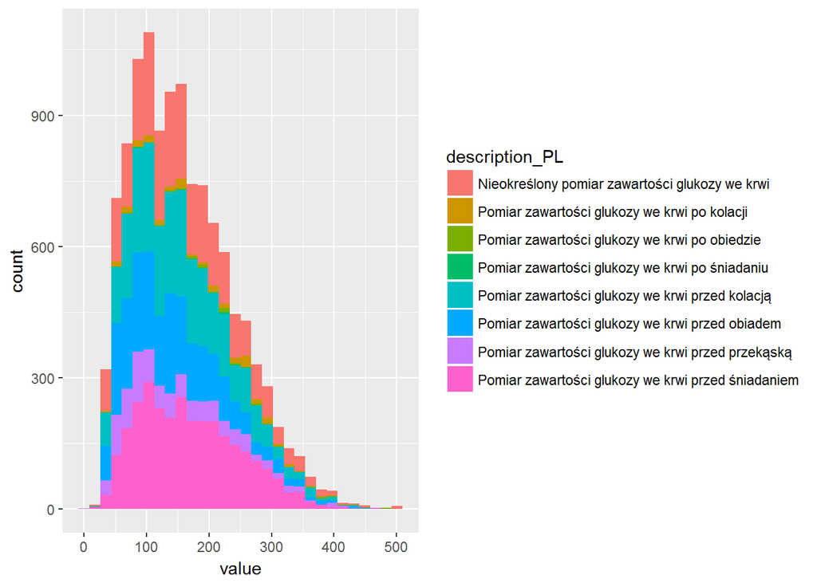

```r
to_hist_pomiar.df <- base.df %>% na.omit() %>% filter(measure==TRUE, type=='pomiar')
ggplot(to_hist_pomiar.df, aes(x=value, fill=description_PL))+geom_histogram()
```

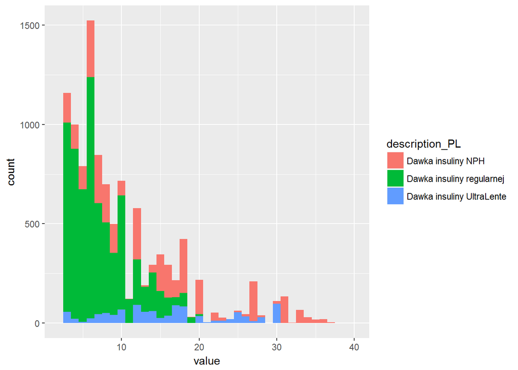

```r
to_hist_dawka.df <- base.df %>% na.omit() %>% filter(measure==TRUE, type=='dawka')
ggplot(to_hist_dawka.df, aes(x=value, fill=description_PL))+geom_histogram(binwidth = 1)+scale_x_continuous(limits = c(2,40))
```

Podział wartości dawek i pomiaru krwi został wykonany na podstawie 20tego i 80tego precentyla. Wartości ponmiędzy uznane zostały jako ‘normalne’, poniżej - ‘niskie’ a powyżej- ‘wysokie’. Poniżej przykład dla pomiaru glukozy we krwi przed kolacją:

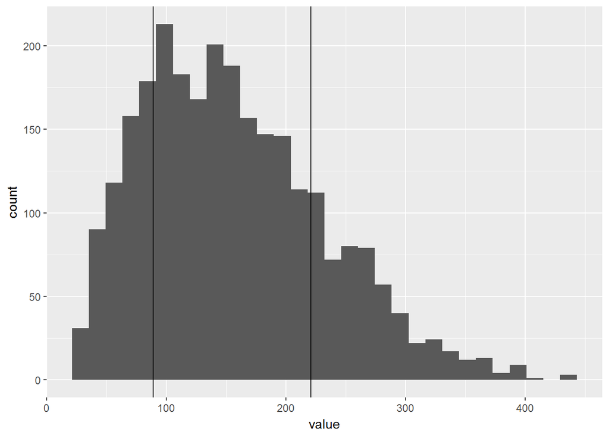

```r
to_hist.df <- base.df %>% na.omit() %>% filter(measure==TRUE, code_id==62)

q <- quantile(to_hist.df$value, c(0.20, 0.80))

ggplot(to_hist.df, aes(x=value))+geom_histogram()+geom_vline(xintercept = c(q[1], q[2]))
```

podział został wykonany dla wszystkich kategorii które zawierają dane mierzalne

```r
to_divide.df <- base.df %>% na.omit() %>% filter(measure==TRUE)
for_loop <- to_divide.df %>% distinct(code_id)
qa = c()
qb = c()
code = c()

for(i in for_loop$code_id){
  to_divide_tmp.df <- base.df %>% na.omit() %>% filter(measure==TRUE, code_id==i)
  qa = c(qa,  quantile(to_divide_tmp.df$value, c(0.20)))
  qb = c(qb,  quantile(to_divide_tmp.df$value, c(0.80)))
  code = c(code, i)

}
df <- data.frame(code,qa,qb)

cluster <- function(code_id, value){

      qa=df[df$code==code_id,"qa"]
      qb=df[df$code==code_id,"qb"]
      if(length(qa)==0 || length(qb)==0 )
        return(NA)

      if(is.na(value))
        return(NA)
      if(is.null(value))
        return(NA)

      if(value<qa){
        return('niski')
        }
      else if(value>qb){
        return('wysoki')
        }
      else if(value>=qa & value<=qb){
        return('normalny')
        }
      else{
        return(NA)}
}

base.df$value.level <- mapply(cluster, base.df$code_id, base.df$value)
```

## Połączenie wartości zmiennych dla tego samego czasu

Następnie łączone są wartości wydarzeń wraz z ich poziomami gdzie jest to aplikowalne:

```r
df <-base.df %>%
  mutate(description = if_else(!is.na(value.level),paste(description_PL,"poziom", value.level), as.character(description_PL)))  %>%
  select(patient_id, time_sek, description)
```

W celu ułatwień obliczeniowych nadane zostały nowe numery ID do każdego połączonego wydarzenia:

```r
new_id <- df %>%arrange(description) %>% distinct(description)
new_id$id <- seq.int(nrow(new_id))

head(new_id)
```

```
##                                 description id
## 1 Aktywność sportowa mniejsza niż zazwyczaj  1
## 2  Aktywność sportowa większa niż zazwyczaj  2
## 3           Dawka insuliny NPH poziom niski  3
## 4        Dawka insuliny NPH poziom normalny  4
## 5          Dawka insuliny NPH poziom wysoki  5
## 6    Dawka insuliny regularnej poziom niski  6
```

Tak przygotowane dane są gotowe do dalszej analizy:

```r
df = inner_join(df, new_id)
head(df)
```

```
##   patient_id time_sek
## 1          1 96772141
## 2          1 96772142
## 3          1 96772143
## 4          1 96800881
## 5          1 96800882
## 6          1 96821461
##                                                          description id
## 1 Pomiar zawartości glukozy we krwi przed śniadaniem poziom normalny 39
## 2                          Dawka insuliny regularnej poziom normalny  7
## 3                                 Dawka insuliny NPH poziom normalny  4
## 4    Pomiar zawartości glukozy we krwi przed kolacją poziom normalny 29
## 5                          Dawka insuliny regularnej poziom normalny  7
## 6     Nieokreślony pomiar zawartości glukozy we krwi poziom normalny 15
```

## Wykrywanie wzorców sekwencyjnych

Zapisano data.frame do pliku .csv aby wygodnie wczytało się dane w trybie sekwencyjnym

```r
write.table(df[,c(1,2,3)], file = "data/clean_data.csv", row.names=FALSE,col.names=FALSE, sep=",")
```

Wczytano dane w postaci z nowoutworzonego pliku

```r
dseq <- read_baskets(con = "data/clean_data.csv", sep =",", info = c("sequenceID","eventID"))
```

Test czy dane zostały wczytane poprawnie, przez ponowną transformację do data.frame

```r
frameS =   as(dseq,"data.frame")
head(frameS)
```

```
##                                                                    items
## 1 {"Pomiar zawartości glukozy we krwi przed śniadaniem poziom normalny"}
## 2                          {"Dawka insuliny regularnej poziom normalny"}
## 3                                 {"Dawka insuliny NPH poziom normalny"}
## 4    {"Pomiar zawartości glukozy we krwi przed kolacją poziom normalny"}
## 5                          {"Dawka insuliny regularnej poziom normalny"}
## 6     {"Nieokreślony pomiar zawartości glukozy we krwi poziom normalny"}
##   sequenceID  eventID
## 1          1 96772141
## 2          1 96772142
## 3          1 96772143
## 4          1 96800881
## 5          1 96800882
## 6          1 96821461
```

Wstępna analiza otrzymanych sekwencji liczba możliwych elementów; częstość zdarzeń:

```r
nitems(dseq)
```

```
## [1] 44
```

```r
freqItem = itemFrequency(dseq)
freqItem = sort(freqItem, decreasing = TRUE )
freqItem
```

```
##                          "Dawka insuliny regularnej poziom normalny"
##                                                         2.225094e-01
##                                 "Dawka insuliny NPH poziom normalny"
##                                                         8.454961e-02
## "Pomiar zawartości glukozy we krwi przed śniadaniem poziom normalny"
##                                                         7.222112e-02
##    "Pomiar zawartości glukozy we krwi przed kolacją poziom normalny"
##                                                         6.335256e-02
##     "Nieokreślony pomiar zawartości glukozy we krwi poziom normalny"
##                                                         6.092663e-02
##    "Pomiar zawartości glukozy we krwi przed obiadem poziom normalny"
##                                                         5.396699e-02
##                             "Dawka insuliny regularnej poziom niski"
##                                                         5.042752e-02
##                            "Dawka insuliny regularnej poziom wysoki"
##                                                         4.163850e-02
##                          "Dawka insuliny UltraLente poziom normalny"
##                                                         2.720223e-02
##                                    "Dawka insuliny NPH poziom niski"
##                                                         2.406045e-02
##   "Pomiar zawartości glukozy we krwi przed śniadaniem poziom wysoki"
##                                                         2.366276e-02
##    "Pomiar zawartości glukozy we krwi przed śniadaniem poziom niski"
##                                                         2.334460e-02
##                                   "Dawka insuliny NPH poziom wysoki"
##                                                         2.294691e-02
##  "Pomiar zawartości glukozy we krwi przed przekąską poziom normalny"
##                                                         2.199244e-02
##      "Pomiar zawartości glukozy we krwi przed kolacją poziom wysoki"
##                                                         2.083913e-02
##       "Pomiar zawartości glukozy we krwi przed kolacją poziom niski"
##                                                         2.071983e-02
##       "Nieokreślony pomiar zawartości glukozy we krwi poziom wysoki"
##                                                         2.032213e-02
##        "Nieokreślony pomiar zawartości glukozy we krwi poziom niski"
##                                                         2.024259e-02
##      "Pomiar zawartości glukozy we krwi przed obiadem poziom wysoki"
##                                                         1.781666e-02
##       "Pomiar zawartości glukozy we krwi przed obiadem poziom niski"
##                                                         1.777689e-02
```

[output cut: 33 more lines]

```
##                                                         5.170014e-04
##     "Pomiar zawartości glukozy we krwi po śniadaniu poziom normalny"
##                                                         5.170014e-04
##        "Pomiar zawartości glukozy we krwi po obiedzie poziom wysoki"
##                                                         4.772321e-04
##                     "Nieokreślony pomiar zawartości glukozy we krwi"
##                                                         1.193080e-04
##        "Pomiar zawartości glukozy we krwi po śniadaniu poziom niski"
##                                                         1.193080e-04
##       "Pomiar zawartości glukozy we krwi po śniadaniu poziom wysoki"
##                                                         1.193080e-04
##                    "Pomiar zawartości glukozy we krwi przed obiadem"
##                                                         1.193080e-04
##                    "Pomiar zawartości glukozy we krwi przed kolacją"
##                                                         7.953868e-05
```

```r
head(freqItem,30)
```

```
##                          "Dawka insuliny regularnej poziom normalny"
##                                                          0.222509445
##                                 "Dawka insuliny NPH poziom normalny"
##                                                          0.084549612
## "Pomiar zawartości glukozy we krwi przed śniadaniem poziom normalny"
##                                                          0.072221118
##    "Pomiar zawartości glukozy we krwi przed kolacją poziom normalny"
##                                                          0.063352555
##     "Nieokreślony pomiar zawartości glukozy we krwi poziom normalny"
##                                                          0.060926626
##    "Pomiar zawartości glukozy we krwi przed obiadem poziom normalny"
##                                                          0.053966991
##                             "Dawka insuliny regularnej poziom niski"
##                                                          0.050427520
##                            "Dawka insuliny regularnej poziom wysoki"
##                                                          0.041638497
##                          "Dawka insuliny UltraLente poziom normalny"
##                                                          0.027202227
##                                    "Dawka insuliny NPH poziom niski"
##                                                          0.024060449
##   "Pomiar zawartości glukozy we krwi przed śniadaniem poziom wysoki"
##                                                          0.023662756
##    "Pomiar zawartości glukozy we krwi przed śniadaniem poziom niski"
##                                                          0.023344601
##                                   "Dawka insuliny NPH poziom wysoki"
##                                                          0.022946908
##  "Pomiar zawartości glukozy we krwi przed przekąską poziom normalny"
##                                                          0.021992444
##      "Pomiar zawartości glukozy we krwi przed kolacją poziom wysoki"
##                                                          0.020839133
##       "Pomiar zawartości glukozy we krwi przed kolacją poziom niski"
##                                                          0.020719825
##       "Nieokreślony pomiar zawartości glukozy we krwi poziom wysoki"
##                                                          0.020322132
##        "Nieokreślony pomiar zawartości glukozy we krwi poziom niski"
##                                                          0.020242593
##      "Pomiar zawartości glukozy we krwi przed obiadem poziom wysoki"
##                                                          0.017816663
##       "Pomiar zawartości glukozy we krwi przed obiadem poziom niski"
##                                                          0.017776894
##                           "Spożycie posiłku większego niż zazwyczaj"
##                                                          0.012606880
##                                                "Objawy hipoglikemii"
##                                                          0.012447803
##                             "Dawka insuliny UltraLente poziom niski"
##                                                          0.008033406
##    "Pomiar zawartości glukozy we krwi przed przekąską poziom wysoki"
##                                                          0.007078942
##     "Pomiar zawartości glukozy we krwi przed przekąską poziom niski"
##                                                          0.006880095
##                            "Dawka insuliny UltraLente poziom wysoki"
##                                                          0.006641479
##                                          "Spożycie typowego posiłku"
##                                                          0.006124478
##                           "Aktywność sportowa większa niż zazwyczaj"
##                                                          0.005527938
##       "Pomiar zawartości glukozy we krwi po kolacji poziom normalny"
##                                                          0.005249553
##                          "Aktywność sportowa mniejsza niż zazwyczaj"
##                                                          0.003897395
```

Po testach proponujemy następujące parametry algorytym cspade:  
- support=0.05: wsparcie ustawiamy dość nisko, żeby “złapać” także reguły związane z wydarzeniami, które wydarzają się rzadko  
- maxsize = 1 wszystkie “koszyki” to jednorazowe zdarzenia, dlatego można zastosować maxsize=1  
- maxgap = 28800 w tym wypadku interesują nas zdarzenia, które występują w zakresie 8 godzin  
- maxlen = 4 zdarzenia w obrębie max 8 godzin dają łączny zakres objawów w ramach doby, co wydaje się rozsądną granicą dla hipoglikemii  
- maxwin - w algorytmie cspade pakietu arulesSequences ma status “disabled”, dlatego nie możemy go użyć.

Następnie wyszukamy wzorce częste i reguły sekwencyjne

```r
parametry = new ("SPparameter",support = 0.05, maxsize = 1, maxgap = 28800, maxlen=4)
wzorce= cspade(dseq, parametry, control = list(verbose = TRUE, tidLists = FALSE, summary= TRUE))
```

```
##
## parameter specification:
## support :  0.05
## maxsize :     1
## maxlen  :     4
## maxgap  : 28800
##
## algorithmic control:
## bfstype  : FALSE
## verbose  :  TRUE
## summary  :  TRUE
## tidLists : FALSE
##
## preprocessing ... 1 partition(s), 0.58 MB [0.13s]
## mining transactions ... 0.2 MB [0.2s]
## reading sequences ... [0.83s]
##
## total elapsed time: 1.16s
```

```r
#odkrycie reguł
reguly = ruleInduction(wzorce,confidence = 0.8)
```

Liczba i podgląd otrzymanych reguł

```r
length(reguly)
```

```
## [1] 1202
```

```r
inspect(head(reguly,10))
```

```
##     lhs                                                                       rhs                                                                       support confidence     lift
##   1 <{"Objawy hipoglikemii"},
##      {"Objawy hipoglikemii"},
##      {"Spożycie posiłku większego niż zazwyczaj"}>                         => <{"Typowa aktywność sportowa"}>                                        0.06060606  1.0000000 3.142857
##   2 <{"Dawka insuliny regularnej poziom niski"},
##      {"Dawka insuliny NPH poziom niski"},
##      {"Objawy hipoglikemii"}>                                              => <{"Typowa aktywność sportowa"}>                                        0.06060606  0.8000000 2.514286
##   3 <{"Dawka insuliny NPH poziom niski"},
##      {"Pomiar zawartości glukozy we krwi przed śniadaniem poziom wysoki"}> => <{"Spożycie posiłku większego niż zazwyczaj"}>                         0.06060606  1.0000000 1.941176
##   4 <{"Dawka insuliny regularnej poziom niski"},
##      {"Dawka insuliny NPH poziom niski"},
##      {"Pomiar zawartości glukozy we krwi przed przekąską poziom wysoki"}>  => <{"Spożycie posiłku większego niż zazwyczaj"}>                         0.07575758  0.8333333 1.617647
##   5 <{"Objawy hipoglikemii"},
##      {"Dawka insuliny NPH poziom niski"},
##      {"Pomiar zawartości glukozy we krwi przed przekąską poziom wysoki"}>  => <{"Spożycie posiłku większego niż zazwyczaj"}>                         0.06060606  1.0000000 1.941176
##   6 <{"Pomiar zawartości glukozy we krwi przed kolacją poziom niski"},
##      {"Dawka insuliny NPH poziom niski"},
##      {"Pomiar zawartości glukozy we krwi przed przekąską poziom wysoki"}>  => <{"Spożycie posiłku większego niż zazwyczaj"}>                         0.09090909  0.8571429 1.663866
##   7 <{"Objawy hipoglikemii"},
##      {"Dawka insuliny regularnej poziom niski"},
##      {"Pomiar zawartości glukozy we krwi przed przekąską poziom wysoki"}>  => <{"Spożycie posiłku większego niż zazwyczaj"}>                         0.06060606  1.0000000 1.941176
##   8 <{"Pomiar zawartości glukozy we krwi przed kolacją poziom niski"},
##      {"Dawka insuliny regularnej poziom niski"},
##      {"Pomiar zawartości glukozy we krwi przed przekąską poziom wysoki"}>  => <{"Spożycie posiłku większego niż zazwyczaj"}>                         0.07575758  1.0000000 1.941176
##   9 <{"Dawka insuliny NPH poziom niski"},
##      {"Objawy hipoglikemii"},
##      {"Pomiar zawartości glukozy we krwi przed przekąską poziom wysoki"}>  => <{"Spożycie posiłku większego niż zazwyczaj"}>                         0.06060606  1.0000000 1.941176
##  10 <{"Pomiar zawartości glukozy we krwi przed obiadem poziom niski"},
##      {"Pomiar zawartości glukozy we krwi przed kolacją poziom niski"},
##      {"Pomiar zawartości glukozy we krwi przed przekąską poziom wysoki"}>  => <{"Spożycie posiłku większego niż zazwyczaj"}>                         0.10606061  0.8750000 1.698529
##
```

Ograniczamy się do reguł nas interesujących - tych które mają “objawy hipoglikemii” po prawej, ale nie po lewej stronie. Sortujemy je według wielkości współczynnika lift.

```r
hipoglik=subset(reguly, !(lhs(reguly) %in% c("\"Objawy hipoglikemii\"")) & rhs(reguly) %in% c("\"Objawy hipoglikemii\""))
hipoglik = sort(hipoglik, by = "lift", decreasing=TRUE)
inspect(hipoglik)
```

```
##     lhs                                                                       rhs                                                                       support confidence     lift
##   1 <{"Dawka insuliny regularnej poziom wysoki"},
##      {"Pomiar zawartości glukozy we krwi przed obiadem poziom niski"},
##      {"Pomiar zawartości glukozy we krwi przed kolacją poziom niski"}>     => <{"Objawy hipoglikemii"}>                                              0.06060606  1.0000000 1.783784
##   2 <{"Dawka insuliny NPH poziom niski"},
##      {"Dawka insuliny NPH poziom normalny"},
##      {"Nieokreślony pomiar zawartości glukozy we krwi poziom niski"}>      => <{"Objawy hipoglikemii"}>                                              0.09090909  1.0000000 1.783784
##   3 <{"Pomiar zawartości glukozy we krwi po kolacji poziom normalny"},
##      {"Dawka insuliny NPH poziom normalny"},
##      {"Nieokreślony pomiar zawartości glukozy we krwi poziom niski"}>      => <{"Objawy hipoglikemii"}>                                              0.07575758  1.0000000 1.783784
##   4 <{"Dawka insuliny NPH poziom niski"},
##      {"Dawka insuliny regularnej poziom niski"},
##      {"Nieokreślony pomiar zawartości glukozy we krwi poziom niski"}>      => <{"Objawy hipoglikemii"}>                                              0.07575758  1.0000000 1.783784
##   5 <{"Pomiar zawartości glukozy we krwi po kolacji poziom normalny"},
##      {"Dawka insuliny regularnej poziom niski"},
##      {"Nieokreślony pomiar zawartości glukozy we krwi poziom niski"}>      => <{"Objawy hipoglikemii"}>                                              0.09090909  1.0000000 1.783784
##   6 <{"Dawka insuliny NPH poziom niski"},
##      {"Dawka insuliny regularnej poziom normalny"},
##      {"Nieokreślony pomiar zawartości glukozy we krwi poziom niski"}>      => <{"Objawy hipoglikemii"}>                                              0.07575758  1.0000000 1.783784
##   7 <{"Dawka insuliny NPH poziom niski"},
##      {"Pomiar zawartości glukozy we krwi po kolacji poziom normalny"},
##      {"Nieokreślony pomiar zawartości glukozy we krwi poziom niski"}>      => <{"Objawy hipoglikemii"}>                                              0.06060606  1.0000000 1.783784
##   8 <{"Dawka insuliny regularnej poziom normalny"},
##      {"Pomiar zawartości glukozy we krwi po kolacji poziom normalny"},
##      {"Nieokreślony pomiar zawartości glukozy we krwi poziom niski"}>      => <{"Objawy hipoglikemii"}>                                              0.07575758  1.0000000 1.783784
##   9 <{"Pomiar zawartości glukozy we krwi przed kolacją poziom normalny"},
##      {"Pomiar zawartości glukozy we krwi po kolacji poziom normalny"},
##      {"Nieokreślony pomiar zawartości glukozy we krwi poziom niski"}>      => <{"Objawy hipoglikemii"}>                                              0.06060606  1.0000000 1.783784
##  10 <{"Pomiar zawartości glukozy we krwi po kolacji poziom normalny"},
##      {"Nieokreślony pomiar zawartości glukozy we krwi poziom niski"}>      => <{"Objawy hipoglikemii"}>                                              0.09090909  0.8571429 1.528958
##  11 <{"Pomiar zawartości glukozy we krwi przed kolacją poziom normalny"},
##      {"Dawka insuliny NPH poziom niski"},
##      {"Pomiar zawartości glukozy we krwi przed przekąską poziom niski"}>   => <{"Objawy hipoglikemii"}>                                              0.06060606  0.8000000 1.427027
##  12 <{"Dawka insuliny NPH poziom niski"},
##      {"Pomiar zawartości glukozy we krwi przed obiadem poziom niski"}>     => <{"Objawy hipoglikemii"}>                                              0.06060606  0.8000000 1.427027
##  13 <{"Dawka insuliny regularnej poziom normalny"},
##      {"Dawka insuliny NPH poziom niski"},
##      {"Pomiar zawartości glukozy we krwi przed obiadem poziom niski"}>     => <{"Objawy hipoglikemii"}>                                              0.06060606  0.8000000 1.427027
##  14 <{"Pomiar zawartości glukozy we krwi przed śniadaniem poziom wysoki"},
##      {"Dawka insuliny NPH poziom niski"},
##      {"Pomiar zawartości glukozy we krwi przed obiadem poziom niski"}>     => <{"Objawy hipoglikemii"}>                                              0.06060606  0.8000000 1.427027
##  15 <{"Spożycie posiłku większego niż zazwyczaj"},
##      {"Pomiar zawartości glukozy we krwi przed obiadem poziom niski"},
##      {"Pomiar zawartości glukozy we krwi przed kolacją poziom niski"}>     => <{"Objawy hipoglikemii"}>                                              0.06060606  0.8000000 1.427027
##
```

## Podsumowanie

Otrzymaliśmy 15 wzorcóW sekwencyjnych, które mogą posłużyć do szybkiego wykrycia i zapobieżenia obajwów hipoglikemii. W większości wypadków ostatnim zdarzeniem bezpośrednio przed wystąpieniem objawów był pomiar wskazujący na niski poziom glukozy we krwi, zwłaśzcza “nieokreślony” - a więc wykonany ad hoc - nie związany z posiłkiem. Świadczy to o tym, że pacjenci byli świadomi swojego stanu, ale nie mogli, bądź nie udało im sie hipoglikemii zapobiec.

Szczególnie interesującą odkrytą regułą jest reguła ostatnia, jako jedyna związana z nawykami żywieniowymi.  
<{“Spożycie posiłku większego niż zazwyczaj”},  
{“Pomiar zawartości glukozy we krwi przed obiadem poziom niski”},  
{“Pomiar zawartości glukozy we krwi przed kolacją poziom niski”}>  
=> <{“Objawy hipoglikemii”}>  
Świadczy ona o tym, że zbyt duże śniadanie, w połączeniu z utrzymującą się niską zawartością glukozy we krwi, może być niebezpieczne dla pacjentów! Być może wypadałoby uczulić ich na taką możliwość w czasie wywiadu.